# Studio Ghibli analysis

ANALYSIS STUDIO GHIBLI FILMOGRAPHY

```python
import pyodbc
import pandas as pd
import seaborn as sb
import matplotlib.pyplot as plt
import datetime as dt
import numpy as np
```

```python
sg = pd.read_excel('studio_ghiblidb.xlsx')
cast = pd.read_excel('cast sgdb.xlsx')
```

The following DataBase containes data about Studio Ghibli, one of the worlds' famous and successful Japanese animation studio . Here you'll find information about the studio filmography; deatails about the movies, casts, leading crew and expensses.

What is in the df?

```python
sg.info()
```

```
<class 'pandas.core.frame.DataFrame'>
RangeIndex: 20 entries, 0 to 19
Data columns (total 15 columns):
 #   Column            Non-Null Count  Dtype
---  ------            --------------  -----
 0   Movieid           20 non-null     int64
 1   MovieName         20 non-null     object
 2   Genre1            20 non-null     object
 3   Genre2            20 non-null     object
 4   Genre3            18 non-null     object
 5   Budget            20 non-null     int64
 6   Revenue           20 non-null     int64
 7   US_Release        18 non-null     datetime64[ns]
 8   JapanReleaseDate  20 non-null     datetime64[ns]
 9   Duration          20 non-null     object
 10  Director          20 non-null     object
 11  Producer          20 non-null     object
 12  ArtDirector       19 non-null     object
 13  Composer          20 non-null     object
 14  writer            20 non-null     object
dtypes: datetime64[ns](2), int64(3), object(10)
memory usage: 2.5+ KB
```

```python
sg.head()
```

|  | Movieid | MovieName | Genre1 | Genre2 | Genre3 | Budget | Revenue | US_Release | JapanReleaseDate | Duration | Director | Producer | ArtDirector | Composer | writer |
| --- | --- | --- | --- | --- | --- | --- | --- | --- | --- | --- | --- | --- | --- | --- | --- |
| 0 | 20 | When Marnie Was There | animation | drama | NaN | 115000000 | 34949567 | 2015-07-26 | 2014-07-14 | 01:43:00 | Hiromasa Yonebayashi | Yoshiaki Nishimura | Yohei Taneda | Takatsugu Muramatsu | Joan G. Robinson |
| 1 | 19 | The Tale of The Princess Kaguya | animation | drama | fantasy | 49300000 | 24366656 | 2014-10-17 | 2013-11-23 | 02:17:00 | Isao Takahata | Yoshiaki Nishimura | Kazuo Komatsubara | Joe Hisaishi | Riko Sakaguchi |
| 2 | 18 | The Wind Rises | animation | drama | romance | 30000000 | 117932401 | 2014-02-21 | 2013-07-20 | 02:06:00 | Hayao Miyazaki | Toshio Suzuki | Yoji Takeshige | Joe Hisaishi | Tatsuo Hori |
| 3 | 16 | The Secret World of Arrietty | animation | fantasy | family | 23000000 | 149480483 | 2012-02-17 | 2010-07-17 | 01:34:00 | Hiromasa Yonebayashi | Toshio Suzuki | Noboru Yoshida/ Yoji Takeshige | Cécile Corbel | Mary Norton |
| 4 | 15 | Ponyo | animation | fantasy | family | 34000000 | 202404009 | 2009-08-14 | 2008-07-19 | 01:40:00 | Hayao Miyazaki | Toshio Suzuki | Noboru Yoshida | Joe Hisaishi | Hayao Miyazaki |

```python
sg.describe()
```

|  | Movieid | Budget | Revenue | US_Release | JapanReleaseDate |
| --- | --- | --- | --- | --- | --- |
| count | 20 | 20 | 20 | 18 | 20 |
| mean | 11 | 27770000 | 81993331 | 2003-09-13 02:40:00 | 1999-12-24 04:48:00 |
| min | 1 | 500000 | 100000 | 1985-06-13 00:00:00 | 1984-03-11 00:00:00 |
| 25% | 6 | 4675000 | 19260510 | 1995-01-16 12:00:00 | 1991-01-20 18:00:00 |
| 50% | 10 | 20500000 | 37974784 | 2004-02-02 12:00:00 | 1996-07-13 00:00:00 |
| 75% | 15 | 31000000 | 153860362 | 2013-08-21 06:00:00 | 2009-01-17 00:00:00 |
| max | 21 | 115000000 | 274925095 | 2023-10-01 00:00:00 | 2023-07-14 00:00:00 |
| std | 6 | 32360471 | 86988427 | NaN | NaN |

The float format had been imported incorrectly, so I reformatted it.

```python
pd.set_option('display.float_format', '{:.0f}'.format)
```

For better analysing i'll add a new column 'Year' based on the column, 'JapanReleaseDate' - the first release of each film

```python
sg = sg.assign(Year = sg['JapanReleaseDate'].dt.year)
```

```python
sg.info()
```

```
<class 'pandas.core.frame.DataFrame'>
RangeIndex: 20 entries, 0 to 19
Data columns (total 16 columns):
 #   Column            Non-Null Count  Dtype
---  ------            --------------  -----
 0   Movieid           20 non-null     int64
 1   MovieName         20 non-null     object
 2   Genre1            20 non-null     object
 3   Genre2            20 non-null     object
 4   Genre3            18 non-null     object
 5   Budget            20 non-null     int64
 6   Revenue           20 non-null     int64
 7   US_Release        18 non-null     datetime64[ns]
 8   JapanReleaseDate  20 non-null     datetime64[ns]
 9   Duration          20 non-null     object
 10  Director          20 non-null     object
 11  Producer          20 non-null     object
 12  ArtDirector       19 non-null     object
 13  Composer          20 non-null     object
 14  writer            20 non-null     object
 15  Year              20 non-null     int32
dtypes: datetime64[ns](2), int32(1), int64(3), object(10)
memory usage: 2.6+ KB
```

In the following queries let's understand the studio financial curve through time:

In which years were Studio Ghibli films released, and were multiple films released in any of those years?

```python
sg.groupby(['Year'])[['Movieid']].count()
```

| Year | Movieid |
| --- | --- |
| 1984 | 1 |
| 1986 | 1 |
| 1988 | 2 |
| 1989 | 1 |
| 1991 | 1 |
| 1992 | 1 |
| 1993 | 1 |
| 1994 | 1 |
| 1995 | 1 |
| 1997 | 1 |
| 2001 | 1 |
| 2004 | 1 |
| 2006 | 1 |
| 2008 | 1 |
| 2010 | 1 |
| 2013 | 2 |
| 2014 | 1 |
| 2023 | 1 |

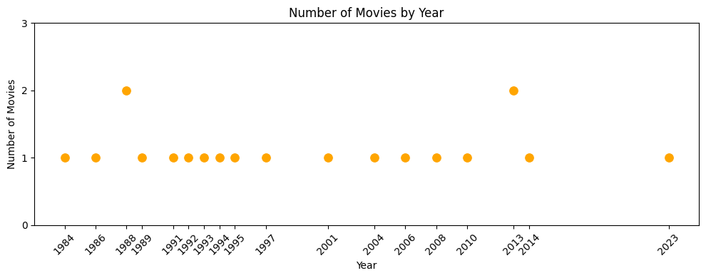

```python
movie_count_by_year = sg.groupby('Year')[['Movieid']].count().reset_index()
movie_count_by_year.columns = ['Year', 'MovieCount']

plt.figure(figsize=(10, 4))
sb.scatterplot(data=movie_count_by_year, x='Year', y='MovieCount', s=100, color='#ffa500')
plt.title('Number of Movies by Year')
plt.xlabel('Year')
plt.ylabel('Number of Movies')
years = movie_count_by_year['Year'].unique()
plt.xticks(years, rotation=45)
y_max = movie_count_by_year['MovieCount'].max()
plt.yticks(range(0, y_max + 2, 1))
plt.tight_layout()
plt.show()
```

What was the sum of revenue vers budget each year?

```python
sg.groupby(['Year'])[['Revenue', 'Budget']].sum()
```

| Year | Revenue | Budget |
| --- | --- | --- |
| 1984 | 3301446 | 500000 |
| 1986 | 15542039 | 3000000 |
| 1988 | 41516962 | 7400000 |
| 1989 | 20500000 | 69000000 |
| 1991 | 473110 | 2500000 |
| 1992 | 34100000 | 9200000 |
| 1993 | 100000 | 5000000 |
| 1994 | 44700000 | 12000000 |
| 1995 | 34900000 | 7000000 |
| 1997 | 169000000 | 23500000 |
| 2001 | 274925095 | 19000000 |
| 2004 | 236049757 | 24000000 |
| 2006 | 68625104 | 22000000 |
| 2008 | 202404009 | 34000000 |
| 2010 | 149480483 | 23000000 |
| 2013 | 142299057 | 79300000 |
| 2014 | 34949567 | 115000000 |
| 2023 | 167000000 | 100000000 |

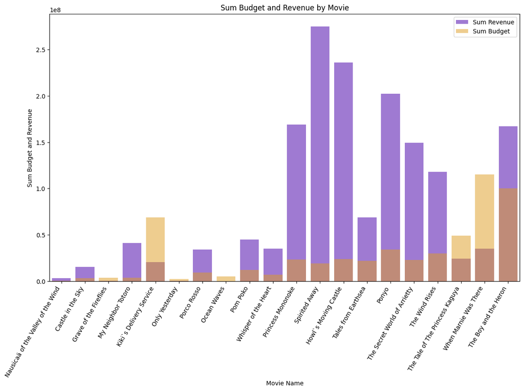

```python
sum_budget_revenue_year = sg.groupby('Movieid')[['Budget', 'Revenue']].sum().reset_index()
sum_budget_revenue_year = pd.merge(sum_budget_revenue_year, sg[['Movieid', 'MovieName']].drop_duplicates(), on='Movieid')
sum_budget_revenue_year = sum_budget_revenue_year.sort_values(by='Movieid')

x_range = sum_budget_revenue_year['Movieid']

plt.figure(figsize=(14, 8))
sb.barplot(data=sum_budget_revenue_year, x='MovieName', y='Revenue', label='Sum Revenue', color='#9c6be1')
sb.barplot(data=sum_budget_revenue_year, x='MovieName', y='Budget', label='Sum Budget', alpha=0.5, color='orange')
plt.legend()
plt.title('Sum Budget and Revenue by Movie')
plt.xlabel('Movie Name')
plt.ylabel('Sum Budget and Revenue')
plt.xticks(rotation=60, ha='right')
plt.show()
```

Let's divide the budget and revnue to two separate grapghs and show it next to revenue per film

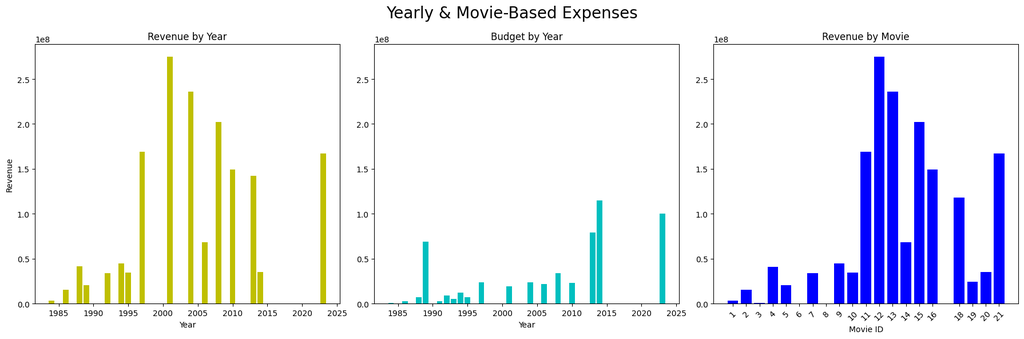

```python
revenue_by_year = sg.groupby(['Year'])[['Revenue']].sum()
budget_by_year = sg.groupby(['Year'])[['Budget']].sum()
revenue_by_movie = sg.groupby('Movieid')[['Revenue']].sum()

plt.figure(figsize=(18, 6))
plt.suptitle('Yearly & Movie-Based Expenses', fontsize=20)

ax1 = plt.subplot(1, 3, 1)
ax1.bar(revenue_by_year.index, revenue_by_year['Revenue'], color='y')
ax1.set_title('Revenue by Year')
ax1.set_xlabel('Year')
ax1.set_ylabel('Revenue')

ax2 = plt.subplot(1, 3, 2, sharey=ax1)
ax2.bar(budget_by_year.index, budget_by_year['Budget'], color='c')
ax2.set_title('Budget by Year')
ax2.set_xlabel('Year')

ax3 = plt.subplot(1, 3, 3, sharey=ax1)
ax3.bar(revenue_by_movie.index, revenue_by_movie['Revenue'], color='b')
ax3.set_title('Revenue by Movie')
ax3.set_xlabel('Movie ID')
movie_ids = revenue_by_movie.index
ax3.set_xticks(movie_ids)
ax3.set_xticklabels(movie_ids, rotation=45)


plt.tight_layout()
plt.show()
```

This DataBase datetime type is based on two source,s the origin relase date in Japan and in the major worldwide boxoffice, the United States:

Which movie was the most profitable and when it was released in Japan and the USA?

```python
sg.loc[sg['Revenue']==sg['Revenue'].max(),['MovieName','Revenue','US_Release', 'JapanReleaseDate']]
```

|  | MovieName | Revenue | US_Release | JapanReleaseDate |
| --- | --- | --- | --- | --- |
| 8 | Spirited Away | 274925095 | 2002-09-20 | 2001-07-20 |

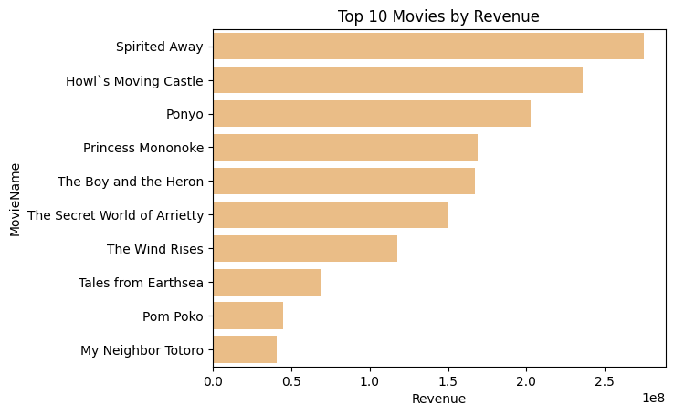

```python
top_10_revenue = sg.nlargest(10, 'Revenue')
sb.barplot(data=top_10_revenue, x='Revenue', y='MovieName', color='#fabe77')
plt.title('Top 10 Movies by Revenue')
plt.show()
```

How many unique genres are in the studio filmography?

```python
sg['Genre3'].unique()
```

```
array([nan, 'fantasy', 'romance', 'family', 'adventure', 'war', 'comedy'],
      dtype=object)
```

```python
sg.loc[sg['Genre3']=='adventure',['MovieName','Genre3']]
```

|  | MovieName | Genre3 |
| --- | --- | --- |
| 6 | Tales from Earthsea | adventure |
| 12 | Princess Mononoke | adventure |
| 13 | Howl`s Moving Castle | adventure |
| 14 | Castle in the Sky | adventure |
| 16 | Pom Poko | adventure |
| 18 | Nausicaä of the Valley of the Wind | adventure |

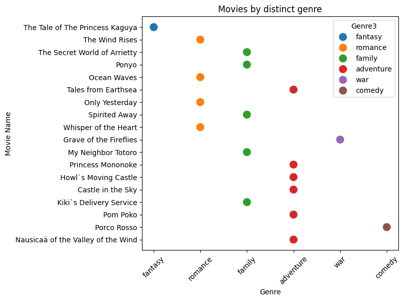

```python
filtered_df = sg[['MovieName', 'Genre3']]

plt.figure(figsize=(8, 6))
sb.scatterplot(data=filtered_df, x='Genre3', y='MovieName', hue='Genre3', palette='tab10', s=150)
plt.title('Movies by distinct genre')
plt.xlabel('Genre')
plt.ylabel('Movie Name')
plt.xticks(rotation=45)
plt.tight_layout()
plt.show()
```

I want to add the human factor and analyse the stodio finance by creators and producors

```python
How many directors worked on how many films
```

```python
sg.groupby(['Director'])[['Movieid']].count()
```

| Director | Movieid |
| --- | --- |
| Goro Miyazaki | 1 |
| Hayao Miyazaki | 11 |
| Hiromasa Yonebayashi | 2 |
| Isao Takahata | 4 |
| Tomomi Mochizuki | 1 |
| Yoshifumi Kondo | 1 |

How many movies were made in the 21st century?

```python
 sg.loc[sg['Year'].between(2000, 2023), ['MovieName', 'Year', 'Budget', 'Revenue', 'Director']]
```

|  | MovieName | Year | Budget | Revenue | Director |
| --- | --- | --- | --- | --- | --- |
| 0 | When Marnie Was There | 2014 | 115000000 | 34949567 | Hiromasa Yonebayashi |
| 1 | The Tale of The Princess Kaguya | 2013 | 49300000 | 24366656 | Isao Takahata |
| 2 | The Wind Rises | 2013 | 30000000 | 117932401 | Hayao Miyazaki |
| 3 | The Secret World of Arrietty | 2010 | 23000000 | 149480483 | Hiromasa Yonebayashi |
| 4 | Ponyo | 2008 | 34000000 | 202404009 | Hayao Miyazaki |
| 6 | Tales from Earthsea | 2006 | 22000000 | 68625104 | Goro Miyazaki |
| 8 | Spirited Away | 2001 | 19000000 | 274925095 | Hayao Miyazaki |
| 13 | Howl`s Moving Castle | 2004 | 24000000 | 236049757 | Hayao Miyazaki |
| 19 | The Boy and the Heron | 2023 | 100000000 | 167000000 | Hayao Miyazaki |

What was the first movie released by Studio Ghibli?

```python
sg.loc[sg['JapanReleaseDate'] == sg['JapanReleaseDate'].min(), ['MovieName', 'JapanReleaseDate', 'Director']]
```

|  | MovieName | JapanReleaseDate | Director |
| --- | --- | --- | --- |
| 18 | Nausicaä of the Valley of the Wind | 1984-03-11 | Hayao Miyazaki |

What was the budget for this, and what revenue did it generate?

```python
sg.loc[sg['MovieName']=='Nausicaä of the Valley of the Wind',['Budget','Revenue']]
```

|  | Budget | Revenue |
| --- | --- | --- |
| 18 | 500000 | 3301446 |

How many movies were released during the studio's first decade of production?

```python
sg.loc[sg['Year'].between(1980,1989), ['MovieName', 'Year', 'Budget', 'Revenue', 'Director']]
```

|  | MovieName | Year | Budget | Revenue | Director |
| --- | --- | --- | --- | --- | --- |
| 10 | Grave of the Fireflies | 1988 | 3700000 | 516962 | Isao Takahata |
| 11 | My Neighbor Totoro | 1988 | 3700000 | 41000000 | Hayao Miyazaki |
| 14 | Castle in the Sky | 1986 | 3000000 | 15542039 | Hayao Miyazaki |
| 15 | Kiki`s Delivery Service | 1989 | 69000000 | 20500000 | Hayao Miyazaki |
| 18 | Nausicaä of the Valley of the Wind | 1984 | 500000 | 3301446 | Hayao Miyazaki |

How many movies were made in each decade since the studio started creating and what was the precentage of each movie from the decade's sum of revenues

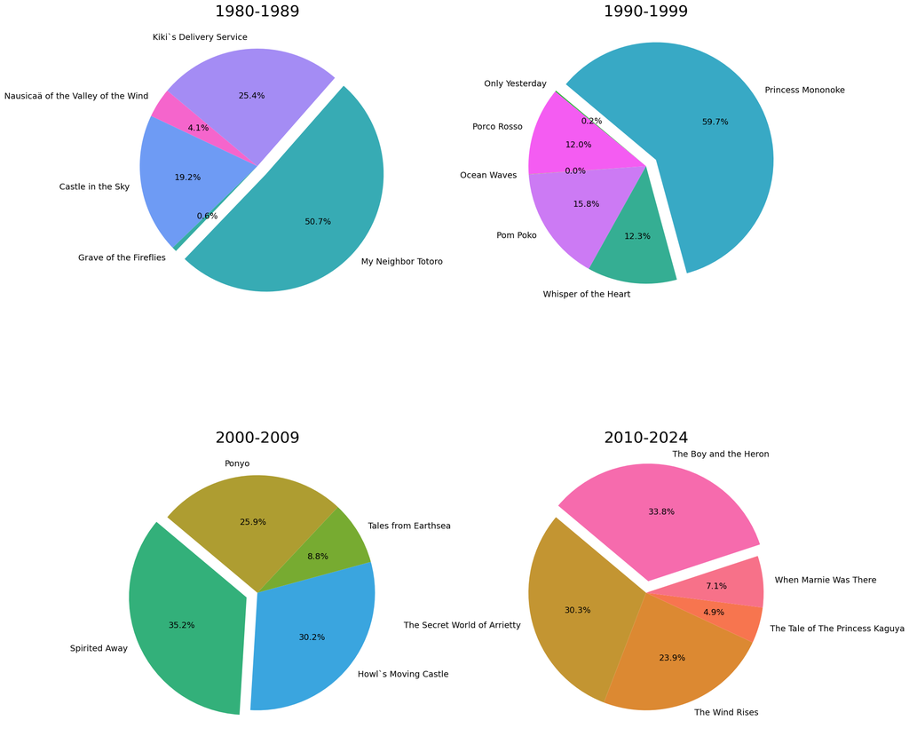

```python
# Generate a unique color for each Movie ID
unique_movie_ids = sg['Movieid'].unique()
colors = sb.color_palette("husl", len(unique_movie_ids))

decades = [
    (1980, 1989),
    (1990, 1999),
    (2000, 2009),
    (2010, 2024)
]

# Create a mapping from Movieid to color
movie_id_to_color = {movie_id: colors[i] for i, movie_id in enumerate(unique_movie_ids)}

# Define a function to format the revenue values
def format_revenue(val):
    if val >= 1e9:
        return f'{val / 1e9:.1f}B'
    elif val >= 1e6:
        return f'{val / 1e6:.1f}M'
    elif val >= 1e3:
        return f'{val / 1e3:.1f}K'
    else:
        return f'{val:.0f}'

fig, axes = plt.subplots(2, 2, figsize=(20, 20))
for i, (start, end) in enumerate(decades):
    ax = axes[i // 2, i % 2]  # Adjust indexing for a 2x2 grid
    df_range = sg[(sg['Year'] >= start) & (sg['Year'] <= end)]
    df_grouped = df_range.groupby('Movieid')['Revenue'].sum().reset_index()

    labels = df_grouped['Movieid'].apply(lambda x: sg[sg['Movieid'] == x]['MovieName'].values[0])
    sizes = df_grouped['Revenue']
    colors = [movie_id_to_color[mid] for mid in df_grouped['Movieid']]
    explode = [0.1 if size == max(sizes) else 0 for size in sizes]
    wedges, texts, autotexts = ax.pie(sizes, labels=labels, colors=colors, explode=explode,
                                      autopct='%1.1f%%',
                                      startangle=140, textprops={'fontsize': 14})
    ax.set_title(f'{start}-{end}', fontsize=26)

    for text in texts + autotexts:
        text.set_fontsize(14)

plt.subplots_adjust(hspace=0.4, wspace=0.00)
plt.tight_layout()
plt.show()
```

Which director made the most revenue for the studio?

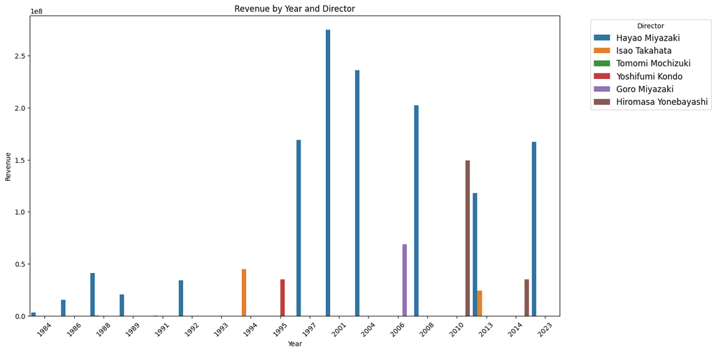

```python
sg = sg.sort_values(by='Year', ascending=True)

plt.figure(figsize=(14, 8))
sb.barplot(data=sg, x="Year", y="Revenue", hue='Director', width=0.9)
plt.xticks(rotation=45)
plt.legend(title='Director', bbox_to_anchor=(1.05, 1), loc='upper left', fontsize='large')
plt.title('Revenue by Year and Director')
plt.xlabel('Year')
plt.ylabel('Revenue')
plt.show()
```

Who was the producer that invested the highest budget?

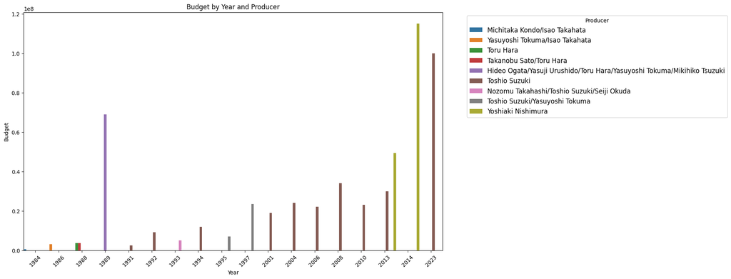

```python
plt.figure(figsize=(14, 8))
sb.barplot(data=sg, x='Year', y='Budget', hue='Producer', width=1)
plt.legend(title='Producer', bbox_to_anchor=(1.05, 1), loc='upper left', fontsize='large')
plt.xticks(rotation=45)
plt.title('Budget by Year and Producer')
plt.show()
```

How many characters are there in each movie?

```python
ch = pd.merge(cast, sg[['Movieid','MovieName']]
              , left_on='MovieId',
             right_on = 'Movieid',
             how='inner')
```

```python
ch.groupby('MovieName')[['CharacterName']].count()
```

| MovieName | CharacterName |
| --- | --- |
| Grave of the Fireflies | 4 |
| Howl`s Moving Castle | 14 |
| Kiki`s Delivery Service | 17 |
| My Neighbor Totoro | 16 |
| Nausicaä of the Valley of the Wind | 13 |
| Ocean Waves | 10 |
| Pom Poko | 19 |
| Ponyo | 17 |
| Porco Rosso | 10 |
| Princess Mononoke | 15 |
| Spirited Away | 15 |
| Tales from Earthsea | 10 |
| The Boy and the Heron | 7 |
| The Secret World of Arrietty | 7 |
| The Tale of The Princess Kaguya | 14 |
| The Wind Rises | 7 |
| When Marnie Was There | 7 |
| Whisper of the Heart | 8 |

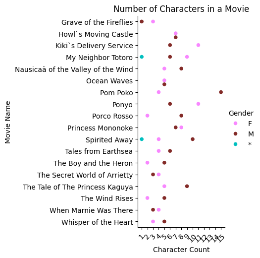

```python
character_count = ch.groupby(['MovieName', 'Gender']).size().reset_index(name='CharacterCount')

sb.catplot(x='CharacterCount', y='MovieName', hue='Gender', data=character_count, kind='swarm', palette=('#f887ff','#832b28','c'),s=30)
plt.title('Number of Characters in a Movie')
plt.xlabel('Character Count')
plt.ylabel('Movie Name')
maxcount = character_count['CharacterCount'].max()
plt.xticks(range(1,maxcount+1), rotation=45)
plt.show()
```

```python
How many of the participating characters are females
```

```python
ch[ch['Gender'] == 'F'].groupby('MovieName')[['CharacterName']].count()
```

| MovieName | CharacterName |
| --- | --- |
| Grave of the Fireflies | 3 |
| Howl`s Moving Castle | 7 |
| Kiki`s Delivery Service | 11 |
| My Neighbor Totoro | 9 |
| Nausicaä of the Valley of the Wind | 5 |
| Ocean Waves | 5 |
| Pom Poko | 4 |
| Ponyo | 11 |
| Porco Rosso | 2 |
| Princess Mononoke | 8 |
| Spirited Away | 4 |
| Tales from Earthsea | 4 |
| The Boy and the Heron | 2 |
| The Secret World of Arrietty | 4 |
| The Tale of The Princess Kaguya | 5 |
| The Wind Rises | 2 |
| When Marnie Was There | 4 |
| Whisper of the Heart | 3 |

Show one movie full cast - characters and dubbing actors from Japan and the USA

```python
ch[ch['MovieName']=='Ponyo']
```

|  | MovieId | CharacterName | japanCastMember | USA_CastMember | Gender | Movieid | MovieName |
| --- | --- | --- | --- | --- | --- | --- | --- |
| 35 | 15 | Lisa | Tomoko Yamaguchi | Tina Fey | F | 15 | Ponyo |
| 36 | 15 | Koichi | Kazushige Nagashima | Matt Damon | M | 15 | Ponyo |
| 37 | 15 | Granmamare | Yuki Amami | Cate Blanchett | F | 15 | Ponyo |
| 38 | 15 | Fujimoto | George Tokoro | Liam Neeson | M | 15 | Ponyo |
| 39 | 15 | Ponyo | Yuria Nara | Noah Cyrus | F | 15 | Ponyo |
| 40 | 15 | Sosuke | Hiroki Doi | Frankie Jonas | M | 15 | Ponyo |
| 41 | 15 | Young Mother | Rumi Hiiragi | Mona Marshall | M | 15 | Ponyo |
| 42 | 15 | Ponyo`s Sisters | Akiko Yano | NaN | F | 15 | Ponyo |
| 43 | 15 | Toki | Kazuko Yoshiyuki | Lily Tomlin | F | 15 | Ponyo |
| 44 | 15 | Yoshie | Tomoko Naraoka | Betty White | F | 15 | Ponyo |
| 45 | 15 | Newscaster | Shin`ich Hatori | Kurt Knutsson | M | 15 | Ponyo |
| 46 | 15 | Kayo | Tokie Hidari | Marsha Clark | F | 15 | Ponyo |
| 47 | 15 | Kumiko | Eimi Hiraoka | Jennessa Rose | F | 15 | Ponyo |
| 48 | 15 | Karen | Nozomi Ohashi | Colleen O`Shaughnessey | F | 15 | Ponyo |
| 49 | 15 | Noriko | Akiko Takeguchi | Cloris Leachman | F | 15 | Ponyo |
| 50 | 15 | Sosuke`s Teacher | Eiko Kanasawa | Courtnee Draper | F | 15 | Ponyo |
| 51 | 15 | Young Father | Shirô Saitô | Bob Bergen | M | 15 | Ponyo |

How many actors have done voice dubbing in more than one movie, who are they from both the Japanese and American casts, and in which movies did they appear?

[figure not shown]

```python
japan_actor_movie_count = ch.groupby('japanCastMember').size().reset_index(name='Count')
actors_more_than_once = japan_actor_movie_count[japan_actor_movie_count['Count'] > 1]

actors_more_than_once_movies = ch[ch['japanCastMember'].isin(actors_more_than_once['japanCastMember'])]
actors_movie_list = actors_more_than_once_movies.groupby('japanCastMember')['MovieName'].apply(lambda x: ', '.join(x)).reset_index()
actors_more_than_once = actors_more_than_once.merge(actors_movie_list, on='japanCastMember')

fig, ax = plt.subplots(figsize=(10, 8))
sb.barplot(data=actors_more_than_once, x='Count', y='japanCastMember', hue='japanCastMember', palette='viridis', ax=ax)
ax.set_title('Japanese Cast Members with More Than One Movie')
ax.set_xlabel('Number of Movies')
ax.set_ylabel('Japanese Cast Member')

# Annotate the bars with movie names
for i in range(len(actors_more_than_once)):
    ax.text(actors_more_than_once['Count'].iloc[i], i, actors_more_than_once['MovieName'].iloc[i], color='w', ha="right", va="center", fontsize=10)

plt.tight_layout()
plt.show()
```

[figure not shown]

```python
us_actor_movie_count = ch.groupby('USA_CastMember').size().reset_index(name='Count')
actors_more_than_once = us_actor_movie_count[us_actor_movie_count['Count'] > 1]

actors_more_than_once_movies = ch[ch['USA_CastMember'].isin(actors_more_than_once['USA_CastMember'])]
actors_movie_list = actors_more_than_once_movies.groupby('USA_CastMember')['MovieName'].apply(lambda x: ', '.join(x.drop_duplicates())).reset_index()
actors_more_than_once = actors_more_than_once.merge(actors_movie_list, on='USA_CastMember')


fig, ax = plt.subplots(figsize=(10, 8))
sb.barplot(data=actors_more_than_once, x='Count', y='USA_CastMember', hue='USA_CastMember', palette='magma', ax=ax)
ax.set_title('USA Cast Members with More Than One Movie')
ax.set_xlabel('Number of Movies')
ax.set_ylabel('American Cast Member')

for i in range(len(actors_more_than_once)):
    ax.text(actors_more_than_once['Count'].iloc[i], i, actors_more_than_once['MovieName'].iloc[i], color='w', ha="right", va="center", fontsize=9)

plt.tight_layout()
plt.show()
```